# IODS course project

Reito Visajaani Salonen

# About the project

Open data science course with quite refreshing starting lesson and instructions.

https://dreafned.github.io/IODS-project/

# 2. Regression and model validation

*Describe the work you have done this week and summarize your learning.*

Dataset is including information for 166 participant for 7 different variables.

```
## 'data.frame':    166 obs. of  7 variables:
##  $ gender  : Factor w/ 2 levels "F","M": 1 2 1 2 2 1 2 1 2 1 ...
##  $ Age     : int  53 55 49 53 49 38 50 37 37 42 ...
##  $ attitude: num  3.7 3.1 2.5 3.5 3.7 3.8 3.5 2.9 3.8 2.1 ...
##  $ deep    : num  3.58 2.92 3.5 3.5 3.67 ...
##  $ stra    : num  3.38 2.75 3.62 3.12 3.62 ...
##  $ surf    : num  2.58 3.17 2.25 2.25 2.83 ...
##  $ Points  : int  25 12 24 10 22 21 21 31 24 26 ...
```

```
## [1] 166   7
```

Variables are having information about participants gender, age and points for cognitive test. There is also included information of attitudes towards statistics as also scoring for levels of thinking as surface, deep, and strategic approaches.

For dataset is remarkable notice dataset to be unbalance with participant gender. Variables are little different by gender, but are mostly behaving simalarly with each other.

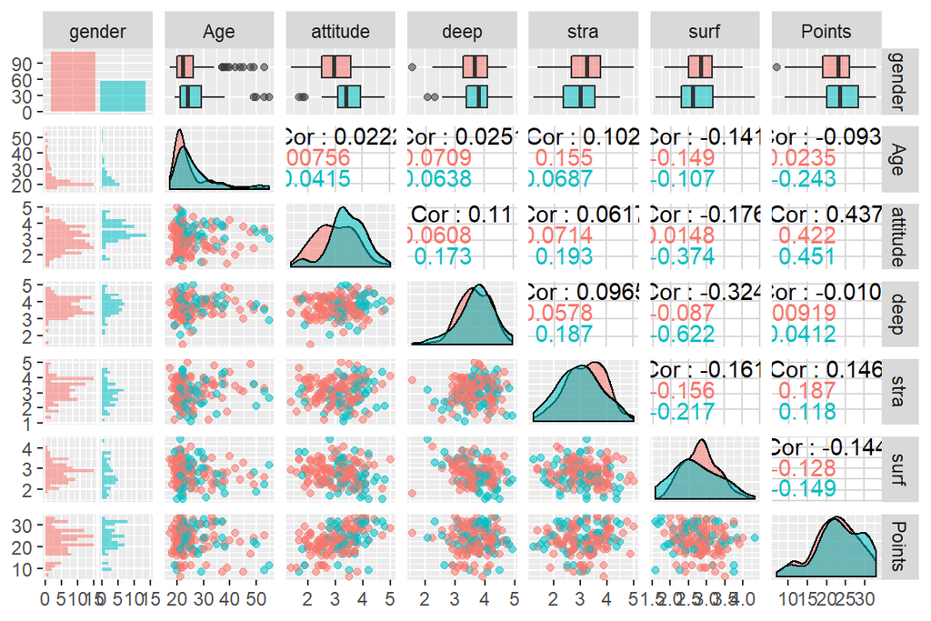

Regarding the general linear model to seek predictors for points in test, I choose to use attitude, deep approach and strategic approach to explain result. Only attitude was found to be significant predictor.

```
##
## Call:
## lm(formula = Points ~ attitude + deep + stra, data = learning2014)
##
## Residuals:
##      Min       1Q   Median       3Q      Max
## -17.5239  -3.4276   0.5474   3.8220  11.5112
##
## Coefficients:
##             Estimate Std. Error t value Pr(>|t|)
## (Intercept)  11.3915     3.4077   3.343  0.00103 **
## attitude      3.5254     0.5683   6.203 4.44e-09 ***
## deep         -0.7492     0.7507  -0.998  0.31974
## stra          0.9621     0.5367   1.793  0.07489 .
## ---
## Signif. codes:  0 '***' 0.001 '**' 0.01 '*' 0.05 '.' 0.1 ' ' 1
##
## Residual standard error: 5.289 on 162 degrees of freedom
## Multiple R-squared:  0.2097, Adjusted R-squared:  0.195
## F-statistic: 14.33 on 3 and 162 DF,  p-value: 2.521e-08
```

```
##
## Call:
## lm(formula = Points ~ attitude, data = learning2014)
##
## Residuals:
##      Min       1Q   Median       3Q      Max
## -16.9763  -3.2119   0.4339   4.1534  10.6645
##
## Coefficients:
##             Estimate Std. Error t value Pr(>|t|)
## (Intercept)  11.6372     1.8303   6.358 1.95e-09 ***
## attitude      3.5255     0.5674   6.214 4.12e-09 ***
## ---
## Signif. codes:  0 '***' 0.001 '**' 0.01 '*' 0.05 '.' 0.1 ' ' 1
##
## Residual standard error: 5.32 on 164 degrees of freedom
## Multiple R-squared:  0.1906, Adjusted R-squared:  0.1856
## F-statistic: 38.61 on 1 and 164 DF,  p-value: 4.119e-09
```

In final model there were only attitude as explaining variable for points in test.

```
##
## Call:
## lm(formula = Points ~ attitude, data = learning2014)
##
## Residuals:
##      Min       1Q   Median       3Q      Max
## -16.9763  -3.2119   0.4339   4.1534  10.6645
##
## Coefficients:
##             Estimate Std. Error t value Pr(>|t|)
## (Intercept)  11.6372     1.8303   6.358 1.95e-09 ***
## attitude      3.5255     0.5674   6.214 4.12e-09 ***
## ---
## Signif. codes:  0 '***' 0.001 '**' 0.01 '*' 0.05 '.' 0.1 ' ' 1
##
## Residual standard error: 5.32 on 164 degrees of freedom
## Multiple R-squared:  0.1906, Adjusted R-squared:  0.1856
## F-statistic: 38.61 on 1 and 164 DF,  p-value: 4.119e-09
```

As looking for data, it seems to be quite well distributed and there is no any significant outlieras in data.

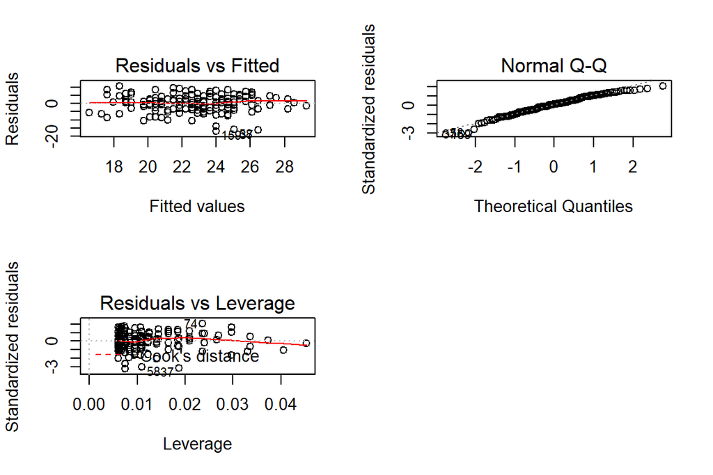

# 3. Logistic Regrssion

## *Describe the work you have done this week and summarize your learning.*

*Describe the work you have done this week and summarize your learning.*

```
## # A tibble: 4 x 4
## # Groups:   sex [2]
##   sex   high_use count mean_grade
##   <fct> <lgl>    <int>      <dbl>
## 1 F     FALSE      156       11.4
## 2 F     TRUE        42       11.7
## 3 M     FALSE      112       12.2
## 4 M     TRUE        72       10.3
```

```
## # A tibble: 8 x 4
## # Groups:   studytime [4]
##   studytime high_use count mean_grade
##       <int> <lgl>    <int>      <dbl>
## 1         1 FALSE       58       10.8
## 2         1 TRUE        42       10.4
## 3         2 FALSE      135       11.8
## 4         2 TRUE        60       10.7
## 5         3 FALSE       52       12.4
## 6         3 TRUE         8       13
## 7         4 FALSE       23       12.3
## 8         4 TRUE         4       12.5
```

```
## # A tibble: 10 x 4
## # Groups:   health [5]
##    health high_use count mean_grade
##     <int> <lgl>    <int>      <dbl>
##  1      1 FALSE       35       12.9
##  2      1 TRUE        11       11.8
##  3      2 FALSE       28       12.0
##  4      2 TRUE        16       10.8
##  5      3 FALSE       62       11.6
##  6      3 TRUE        19       10.6
##  7      4 FALSE       49       11.8
##  8      4 TRUE        18       10.4
##  9      5 FALSE       94       11.3
## 10      5 TRUE        50       10.8
```

```
## # A tibble: 10 x 4
## # Groups:   famrel [5]
##    famrel high_use count mean_grade
##     <int> <lgl>    <int>      <dbl>
##  1      1 FALSE        6       11.8
##  2      1 TRUE         2       12
##  3      2 FALSE       10       10.5
##  4      2 TRUE         9       10.7
##  5      3 FALSE       39       11.4
##  6      3 TRUE        25       10.8
##  7      4 FALSE      135       11.7
##  8      4 TRUE        54       11.0
##  9      5 FALSE       78       12.2
## 10      5 TRUE        24       10.2
```

```
##  [1] "school"     "sex"        "age"        "address"    "famsize"
##  [6] "Pstatus"    "Medu"       "Fedu"       "Mjob"       "Fjob"
## [11] "reason"     "nursery"    "internet"   "guardian"   "traveltime"
## [16] "studytime"  "failures"   "schoolsup"  "famsup"     "paid"
## [21] "activities" "higher"     "romantic"   "famrel"     "freetime"
## [26] "goout"      "Dalc"       "Walc"       "health"     "absences"
## [31] "G1"         "G2"         "G3"         "alc_use"    "high_use"
```

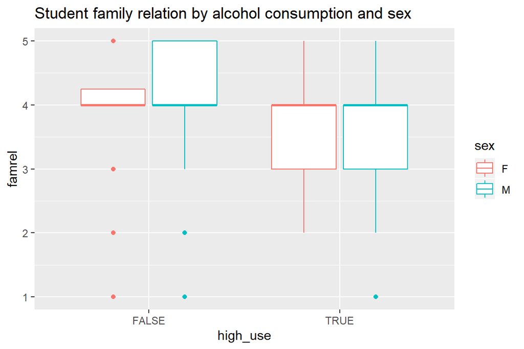

```
##
## Call:
## glm(formula = high_use ~ famrel + studytime + health + sex, family = "binomial",
##     data = alc)
##
## Deviance Residuals:
##     Min       1Q   Median       3Q      Max
## -1.4630  -0.8632  -0.6525   1.1891   2.1629
##
## Coefficients:
##             Estimate Std. Error z value Pr(>|z|)
## (Intercept)  0.64999    0.65100   0.998  0.31806
## famrel      -0.30716    0.12677  -2.423  0.01540 *
## studytime   -0.46050    0.15662  -2.940  0.00328 **
## health       0.06094    0.08539   0.714  0.47543
## sexM         0.70691    0.24605   2.873  0.00407 **
## ---
## Signif. codes:  0 '***' 0.001 '**' 0.01 '*' 0.05 '.' 0.1 ' ' 1
##
## (Dispersion parameter for binomial family taken to be 1)
##
##     Null deviance: 465.68  on 381  degrees of freedom
## Residual deviance: 434.61  on 377  degrees of freedom
## AIC: 444.61
##
## Number of Fisher Scoring iterations: 4
```

```
## (Intercept)      famrel   studytime      health        sexM
##  0.64999130 -0.30715569 -0.46049830  0.06094206  0.70690830
```

```
##                    OR     2.5 %    97.5 %
## (Intercept) 1.9155242 0.5347331 6.9210174
## famrel      0.7355361 0.5727234 0.9431068
## studytime   0.6309692 0.4600066 0.8515317
## health      1.0628373 0.9002538 1.2591968
## sexM        2.0277125 1.2550344 3.2989913
```

```
##     famrel studytime health sex high_use probability prediction
## 373      4         1      5   M    FALSE   0.4931226      FALSE
## 374      5         1      3   M     TRUE   0.3878043      FALSE
## 375      5         3      4   F    FALSE   0.1167561      FALSE
## 376      4         1      5   F    FALSE   0.3242257      FALSE
## 377      5         3      5   F    FALSE   0.1231890      FALSE
## 378      4         2      1   F    FALSE   0.1917489      FALSE
## 379      2         2      5   F    FALSE   0.3587931      FALSE
## 380      1         2      5   F    FALSE   0.4320601      FALSE
## 381      2         1      2   M     TRUE   0.5996421       TRUE
## 382      4         1      5   M     TRUE   0.4931226      FALSE
```

```
##         prediction
## high_use FALSE TRUE
##    FALSE   255   13
##    TRUE    102   12
```

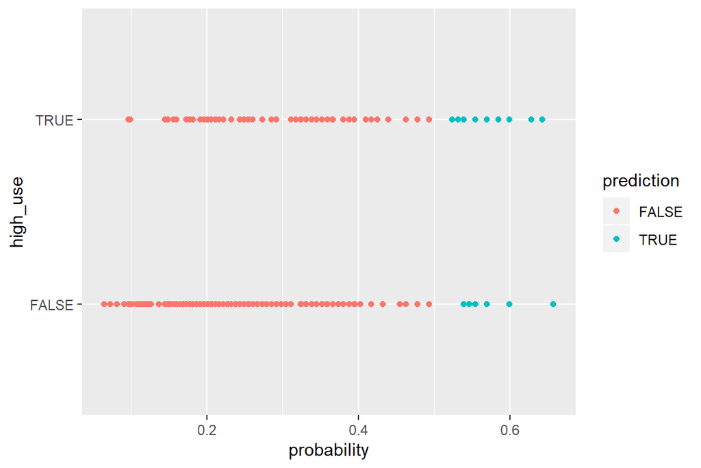

```
##         prediction
## high_use      FALSE       TRUE        Sum
##    FALSE 0.66753927 0.03403141 0.70157068
##    TRUE  0.26701571 0.03141361 0.29842932
##    Sum   0.93455497 0.06544503 1.00000000
```

```
## [1] 0.3010471
```

```
## [1] 0.3010471
```

```
## [1] 0.3036649
```